# Check 4: Decision consistency

Conducting the analysis with stateELP

Guide home | Previous: Check 3: Academic patterns | Next: Decision: Synthesis and next steps

**Simulated data**

Every output on this page comes from the package’s simulated data. It shows what this step produces and how to read it. It says nothing about any real state: every gap, ratio and rate here comes from how the data were generated.

```r
library(stateELP)
```

## What this step answers

Suppose the exit threshold were set only by how English language proficiency (ELP) lines up with proficiency on the content test. Where would it land, and how does the current rule compare?

The stage works on the ELP **level**. A **cut** is a candidate threshold on that level. At each cut, every current English learner (EL) is classified twice: *ready to exit* or not by ELP level (at or above the cut), and *proficient* or not on the same year’s content test. Two statistics summarize how the classifications line up:

- **Decision consistency** (agreement): the share of students the two classifications agree on.
- **Youden’s J**: sensitivity plus specificity, minus one. **Sensitivity** is the share of proficient students the cut calls ready; **specificity** is the share of not-proficient students it calls not ready. J is 0 when a cut separates nothing and 1 when it separates perfectly.

**J is the primary statistic**, and the cut where it is highest is the **J optimum**. The reason is the **base rate**, the share of current ELs who are proficient. It is usually well below one half, and then agreement is pulled toward calling everyone “not ready”. J weights the two kinds of error equally *as rates*, however common each group is.

**Why the level, not the scale score.** The exit rule is written on the level, so the rule and the J optimum can share one axis. The spec declares a range only for the level scale; it has no map from scale scores to levels (`elp$cuts` is `NULL`). Scale scores depend on grade, so a scale-score optimum would not compare across grades. And some instruments report only a level.

Check 3 shows content scores by ELP band. Check 4 turns the same pairing into a yes/no classification. The two are read together.

## Sample

**Cross-sectional: every current EL in one grade and one year with both a same-year annual ELP level and a same-year content score in one subject.** The level is on the component the spec names for every stage (`spec$elp$headline`): the “Overall Composite” in the simulated spec, which is also what the exit rule is written on.

This is the current-EL part of Check 3’s paired cross-section, **not** the entry cohort of Checks 1 and 2 (students who entered EL status in the same grade and year, followed forward). Left out are former ELs and English-only students (they have no ELP level to classify), students on an alternate academic assessment (another score scale), current ELs with no annual ELP level that year, and any level outside the spec’s declared scale (counted in `res$meta$n_out_of_scale`).

Each grade × subject × year is its own **panel**; grades are never pooled. By default `run_check4()` takes the panel Check 3’s `compute_panel()` derives: the spec’s first academic subject, its first tested grade, and the latest year with academic rows. Both stages call the same function, so they describe the same students. Scores are paired within the school year, not to the day.

## Status in the package

**First pass built**

The stage computes and renders one grade × subject panel. Three of its six result slots are built; the other three are `NULL` by design.

| Slot | Status | What it holds |
| --- | --- | --- |
| `$consistency_curve` | Built | Classification counts and agreement at every candidate cut |
| `$youden_j` | Built | The same rows, plus sensitivity, specificity and J |
| `$j_optimal` | Built | One row per panel: J optimum, highest agreement, current rule, error-tolerance reading |
| `$candidate_region` | `NULL`: later pass | The region across grades, annotated with Check 1’s reliability |
| `$dependence` | `NULL`: no package support | The copula / Kendall’s-tau dependence analysis |
| `$policy_as_whole` | `NULL`: Type-gated, not built | The whole multi-criterion rule as a classifier (Types 2–6) |

What this means for you:

- **One panel per call.** Use the `subject`, `grade` and `year` arguments for others; “How to read it” loops over grades.
- **The candidate region is yours to write for now**, by hand.
- **Prep 3 is not built**, so the error-tolerance answer is read straight from `spec$policy$error_tolerance`. The simulated spec says `"unknown"`.
- **Some choices await confirmation** in the package’s build notes: the suppression rule, tie-breaking (lowest tied cut wins), the per-student reading of error tolerance, and the comparison with Check 3.

## Before you start

You need:

- **An `el_data` bundle with an academic table** (see Setup).
- **Decimal ELP levels** if your instrument reports them. The candidate cuts are the distinct levels the delivery carries, so whole numbers give few.
- **A spec that declares** the level scale and bands (`elp$level_scale`, `elp$bands`); the exit rule as structured terms (`policy$exit`); the academic subjects, grades and cut scores (`academic`) with the proficient level (`policy$academic_benchmark$proficient_level`); the suppression minimum (`policy$suppression$min_cell`), the smallest group a published number may describe; and Prep 3’s answer (`policy$error_tolerance`), or `"unknown"`.
- **Check 3’s results at hand.** Check 4 does not need them to run, but you read the two together.

Build the spec and bundle once, and look at what the stage will read:

```r
spec <- read_el_spec("00_SIM_EL_Spec")
bundle <- as_el_data(el_long_sim, roster = el_roster_sim,
                     academic = academic_long_sim, spec = spec)

spec_headline_label(spec)              # the ELP component the stages use
```

```
[1] "Overall Composite"
```

```r
spec$elp$level_scale$range             # the level scale the cuts live on
```

```
[1] 1 6
```

```r
spec$policy$exit$pathways[[1]]$rule    # the current rule, as written
```

```
[1] "Overall composite proficiency level >= 4.5"
```

```r
spec$policy$error_tolerance$costlier_error
```

```
[1] "unknown"
```

```r
spec_min_cell(spec)
```

```
[1] 10
```

Then check which panel the stage will draw, and how many students it can draw on:

```r
panel <- compute_panel(bundle, spec)
panel[c("subject", "grade", "year")]
```

```
$subject
[1] "ELA"

$grade
[1] "3"

$year
[1] 2025
```

```r
cov <- el_coverage(bundle)
cov[cov$YEAR == panel$year & cov$GRADE == panel$grade,
    c("YEAR", "GRADE", "N_CURRENT", "N_CURRENT_ELP", "N_ALTERNATE")]
```

```
# A tibble: 1 × 5
   YEAR GRADE N_CURRENT N_CURRENT_ELP N_ALTERNATE
  <int> <chr>     <int>         <int>       <int>
1  2025 3          2846          2695          10
```

`N_ALTERNATE` counts current ELs on the alternate ELP form. They have no annual level, so they are outside the sample too. The paired sample is smaller than `N_CURRENT_ELP`, because each student also needs a content score in the subject.

**What degrades to `NULL`.** The stage never crashes on a missing input; it empties the slot and says why in `res$meta$note`. With no academic table, or a spec that declares no academic subject (the shipped ELPA21 example points to a separate academic spec), every slot is `NULL`. So is a panel that cannot be derived; the R error is kept in `res$meta$panel_error`. With no proficiency cut, or no student with both scores, the curves are `NULL`. If the exit rule has no term on the component’s own level, the curves are drawn without a rule marked, and `res$meta$threshold_note` says why.

## Run it

```r
res <- run_check4(bundle, spec)
names(res)
```

```
[1] "consistency_curve" "youden_j"          "j_optimal"
[4] "candidate_region"  "dependence"        "policy_as_whole"
[7] "meta"
```

`run_check4()` takes the panel and calls three functions in order. You can run them yourself to inspect each step:

```r
curve <- compute_consistency_curve(bundle, spec, panel)
yj    <- compute_youden_j(curve)
opt   <- compute_j_optimal(yj, spec)
identical(opt, res$j_optimal)
```

```
[1] TRUE
```

For another panel: `run_check4(bundle, spec, subject = "Math", grade = "8")`. A subject or grade the spec does not declare is an error, not a silent switch.

## What you get

### The Sample statement

Read it first:

```r
cat(res$meta$sample)
```

Cross-sectional – the same paired cross-section as Data Check 3, not the entry cohort Data Checks 1 and 2 follow: **every current grade-3 EL with both a 2025 Overall Composite level and a 2025 ELA score** (n = 2,596). Former ELs and English-only students are not in it: the two classifications compared here exist only for students still classified. Each grade is a panel of its own and grades are never pooled; this pass renders one, grade 3 ELA.

### The figure

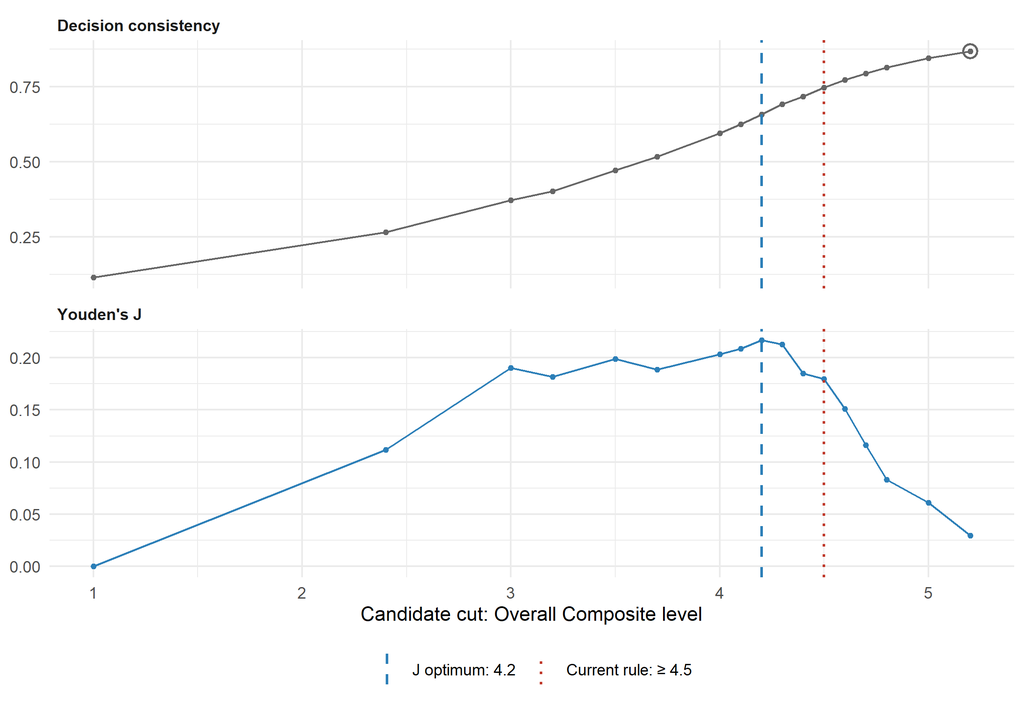

```r
plot_consistency_curve(res$youden_j, res$j_optimal, spec)
```

Agreement is on top and J below, each on its own vertical scale. The dashed line is the J optimum, the dotted line the current rule, and the circle agreement’s highest reportable point. Suppressed cuts are not drawn.

### The optimum

The stage report’s summary table:

```r
ft_check4_optimum(res)
```

| Subject | Grade | n | Proficient | J optimum | J there | Highest reportable agreement | Agreement there | Current rule | J at the rule |
| --- | --- | --- | --- | --- | --- | --- | --- | --- | --- |
| ELA | 3 | 2,596 | 11% | 4.2 | 0.22 | 5.2 | 87% | ≥ 4.5 | 0.18 |

The full `$j_optimal` row carries more:

```r
o <- res$j_optimal
o[, c("N", "BASE_RATE", "J_CUT", "J", "N_J_TIED", "J_MAX_HIDDEN")]
```

```
# A tibble: 1 × 6
      N BASE_RATE J_CUT     J N_J_TIED J_MAX_HIDDEN
  <int>     <dbl> <dbl> <dbl>    <int> <lgl>
1  2596     0.115   4.2 0.217        1 FALSE
```

```r
o[, c("AGREE_CUT", "AGREE", "AGREE_FLOOR", "OPTIMA_DIVERGE")]
```

```
# A tibble: 1 × 4
  AGREE_CUT AGREE AGREE_FLOOR OPTIMA_DIVERGE
      <dbl> <dbl>       <dbl> <lgl>
1       5.2 0.867       0.885 TRUE
```

```r
o[, c("THRESHOLD", "THRESHOLD_CUT", "THRESHOLD_SIDE", "J_AT_THRESHOLD")]
```

```
# A tibble: 1 × 4
  THRESHOLD THRESHOLD_CUT THRESHOLD_SIDE J_AT_THRESHOLD
      <dbl>         <dbl> <chr>                   <dbl>
1       4.5           4.5 above                   0.180
```

```r
o[, c("IMPLIED_COST_RATIO", "COSTLIER_ERROR", "LEAN", "NO_OPTIMUM")]
```

```
# A tibble: 1 × 4
  IMPLIED_COST_RATIO COSTLIER_ERROR LEAN  NO_OPTIMUM
               <dbl> <chr>          <chr> <chr>
1               7.71 unknown        <NA>  <NA>
```

### The curve, cut by cut

`$youden_j` has one row per candidate cut. The cuts that can be shown:

```r
y <- res$youden_j
y[!y$SUPPRESSED,
  c("CUT", "TP", "FP", "FN", "TN", "AGREE", "SENSITIVITY", "SPECIFICITY", "J")]
```

```
# A tibble: 17 × 9
     CUT    TP    FP    FN    TN AGREE SENSITIVITY SPECIFICITY      J
   <dbl> <int> <int> <int> <int> <dbl>       <dbl>       <dbl>  <dbl>
 1   1     298  2298     0     0 0.115      1            0     0
 2   2.4   278  1887    20   411 0.265      0.933        0.179 0.112
 3   3     264  1598    34   700 0.371      0.886        0.305 0.191
 4   3.2   249  1503    49   795 0.402      0.836        0.346 0.182
 5   3.5   228  1301    70   997 0.472      0.765        0.434 0.199
 6   3.7   207  1163    91  1135 0.517      0.695        0.494 0.189
 7   4     182   936   116  1362 0.595      0.611        0.593 0.203
 8   4.1   172   847   126  1451 0.625      0.577        0.631 0.209
 9   4.2   162   751   136  1547 0.658      0.544        0.673 0.217
10   4.3   148   652   150  1646 0.691      0.497        0.716 0.213
11   4.4   128   562   170  1736 0.718      0.430        0.755 0.185
12   4.5   115   474   183  1824 0.747      0.386        0.794 0.180
13   4.6    95   386   203  1912 0.773      0.319        0.832 0.151
14   4.7    75   311   223  1987 0.794      0.252        0.865 0.116
15   4.8    56   241   242  2057 0.814      0.188        0.895 0.0830
16   5      36   138   262  2160 0.846      0.121        0.940 0.0608
17   5.2    17    63   281  2235 0.867      0.0570       0.973 0.0296
```

The four counts are a two-by-two table at that cut. `TP`: proficient and at or above the cut. `FP`: not proficient but at or above it (a premature exit, if this were the rule). `FN`: proficient but below it (held back). `TN`: not proficient and below it. `AGREE` is `(TP + TN) / N`; `J` is `TP / (TP + FN) + TN / (TN + FP) - 1`. `ft_check4_curve(res)` is the report’s version, listing every cut with suppressed ones as dashes.

**Suppression.** Here 17 of 49 cuts can be shown. A blanked cut keeps its row, `CUT` and `N`; its counts and rates are `NA` and `SUPPRESSED` is `TRUE`. A cut is blanked when one of its cells is a non-zero count below `min_cell`, or when subtracting it from a neighboring published count, including Check 3’s band counts, would reveal a group that small. And if the ELP bands whose shares Check 3 cannot show hold, together, a small group of proficient or not-proficient students, every cut is blanked. The J optimum is the best *reportable* cut. Small panels can lose the curve entirely: in the package’s own experiments, most panels of about 160 students reported no optimum.

### The notes

The sentences the report prints beside the figure:

```r
cat(check4_optimum_note(res), "\n\n")
```

In grade 3 ELA, 11% of the 2,596 current ELs reached proficiency. Youden’s J is highest, among the cuts that can be shown, at 4.2 (J = 0.22). Raw agreement’s highest reportable point is elsewhere, at 5.2 (87%), no better than simply calling every student not ready, which agrees 89% of the time. That is the base-rate pull, and it is why the J optimum, not the agreement peak, is this stage’s optimal-cut statistic. Some cuts are suppressed, so agreement’s true maximum may lie among them. The current rule (≥ 4.5) sits above the J optimum, where J = 0.18.

```r
cat(check4_tolerance_note(res), "\n")
```

Which error costs more is still an open question: Prep 3 has not recorded an answer. Youden’s J weights the two errors equally as rates – the share of proficient students held back and the share of not-proficient students exited – however common each group is. Per student that is not an even trade: with 11% of these students proficient, the J optimum of 4.2 weighs holding back one proficient student as heavily as exiting 7.7 who are not. If stakeholders price the two errors differently from that, it is a documented reason to land the threshold deliberately above or below the J optimum – a values input, not a departure from the evidence.

`res$meta` also holds `axis_note`, `pairing_note`, `threshold_note`, `resolution_note`, `dependence_note` and `policy_as_whole_note`. A note is `NA` when it does not apply. Here that is true of the threshold and resolution notes.

### The empty slots

```r
vapply(res[c("candidate_region", "dependence", "policy_as_whole")],
       is.null, logical(1))
```

```
candidate_region       dependence  policy_as_whole
            TRUE             TRUE             TRUE
```

```r
res$meta$pending
```

```
[1] "candidate_region"
```

`$meta$pending` lists slots that apply to this spec but are not built. `$dependence` is not listed: the method has no package support yet.

## How to read it

### The base-rate pull

Agreement equals the base rate times sensitivity plus (one minus the base rate) times specificity. With a low base rate, specificity dominates: calling everyone “not ready” already agrees for every non-proficient student.

In this panel 11% of 2,596 current ELs are proficient, so calling everyone not ready agrees 89% of the time. Agreement’s highest reportable point, 87% at 5.2 (the highest cut that can be shown), does not even beat that floor. J peaks at 4.2 (J = 0.22). These come from the generator’s settings; they show the method’s behavior, not a finding.

In general, when proficiency rises with level, agreement peaks where the proficiency rate among students *at a level* crosses one half, and J where it crosses the *overall base rate*. So when the base rate is below one half, the J optimum sits at or below agreement’s peak, usually well below.

**Confirm you are computing J, not agreement relabeled.** This is the stage’s checkpoint. The package tests it on a fixture with a 16% base rate where the two optima differ by construction. On your own output:

```r
with(res$youden_j, all.equal(J, TP / (TP + FN) + TN / (TN + FP) - 1))
```

```
[1] TRUE
```

```r
res$j_optimal$OPTIMA_DIVERGE
```

```
[1] TRUE
```

The first line recomputes J from the four counts. The second says whether the two optima differ in this panel. `FALSE` is not by itself an error: the two can land on the same cut, especially when the base rate is near one half. What must hold is that the reported optimum is J’s.

### The shape, not only the peak

A flat top means several cuts separate students almost equally well. Here the shown cuts around the optimum read 4.0 (J = 0.20), 4.1 (J = 0.21), 4.2 (J = 0.22), 4.3 (J = 0.21). The optimum alone overstates how precisely the data locate a threshold, which is why the stage’s eventual output is a *region*.

### The current rule against the optimum

The current rule (level ≥ 4.5) sits above the J optimum here, with J = 0.18 against 0.22 at the optimum. That difference is the separation the rule gives up on this one criterion, content proficiency in this grade.

Read the right-hand end of the axis with care. A student still an EL at or above the exit level is, in most states, in their final year, so those cuts rest on students on their way out. In the simulated data every current EL at or above 4.5 is in their exit year.

### Error tolerance: what J assumes

J weights the two errors equally **as rates**, not per student. Maximizing J is the same as minimizing `FP + R × FN`, with `R = (1 − base rate) / base rate`, reported as `IMPLIED_COST_RATIO`. Here `R` is 7.7: at the J optimum, holding back one proficient student counts as much as exiting 7.7 who are not proficient.

Prep 3 (not yet built) asks stakeholders which error is costlier for a student: exiting them prematurely, or holding them longer than necessary. The package reads the answer per student, and `LEAN` gives the side of the reported J optimum it points to:

- **Premature exit costlier:** `"above"` whenever the base rate is at or below one half; otherwise `NA`.
- **Equal per student:** `"above"`, toward agreement’s maximum, when the base rate is below one half, and `"below"` when it is above. It is `"at"` when the J optimum is itself agreement’s maximum, beats the everyone-not-ready floor, and no suppressed cut lies above it.
- **Prolonged retention costlier:** `"below"` only if a hold is judged more than `R` times as costly. Prep 3 does not record how much, so `LEAN` is `NA` unless the base rate is at least one half (`R` at most 1).

Trying each answer on a copy of the spec (hypothetical answers, not anything a state said):

```r
answers <- c("premature_exit", "equal", "prolonged_retention")
vapply(answers, function(a) {
  s <- spec
  s$policy$error_tolerance$costlier_error <- a
  compute_j_optimal(res$youden_j, s)$LEAN
}, character(1))
```

```
     premature_exit               equal prolonged_retention
            "above"             "above"                  NA
```

With `"unknown"`, `LEAN` is `NA` and the note says the question is open. A stated asymmetry is a documented reason to land above or below the J optimum: a values input, not a departure from the evidence. This per-student reading awaits confirmation. To record a real answer, set `costlier_error`, `asked_of`, `asked_date`, `rationale` and `source` under `policy$error_tolerance` in your spec.

### Across grades

The report shows one panel, but the evidence is read across grades. Until the candidate-region pass exists, run each grade and keep the panels apart:

```r
grades <- spec_academic_grades(spec, "ELA")
ela <- lapply(grades, function(g) {
  run_check4(bundle, spec, subject = "ELA", grade = g)
})
ela_opt <- dplyr::bind_rows(lapply(ela, function(r) r$j_optimal))
ela_opt[, c("GRADE", "N", "BASE_RATE", "J_CUT", "J", "J_MAX_HIDDEN",
            "AGREE_CUT", "THRESHOLD_SIDE")]
```

```
# A tibble: 9 × 8
  GRADE     N BASE_RATE J_CUT     J J_MAX_HIDDEN AGREE_CUT THRESHOLD_SIDE
  <chr> <int>     <dbl> <dbl> <dbl> <lgl>            <dbl> <chr>
1 3      2596     0.115   4.2 0.217 FALSE              5.2 above
2 4      2102     0.150   4   0.211 TRUE               5.2 above
3 5      1765     0.146   3.6 0.224 TRUE               5.2 above
4 6      1607     0.174   3.6 0.206 TRUE               5   above
5 7      1423     0.212   3.8 0.254 TRUE               5.2 above
6 8      1270     0.235   3.5 0.220 FALSE              5.2 above
7 9      1182     0.276   3.8 0.194 FALSE              5   above
8 10     1082     0.338   4   0.148 FALSE              5   above
9 11      961     0.373   3.6 0.188 FALSE              4.8 above
```

Each row is its own panel. Here the J optima run from 3.5 to 4.2, and the rule sits above the optimum in 9 of 9 grades: patterns the simulation built in. Each panel takes the latest year by default. On real data, look at whether the optima cluster, which rows have `J_MAX_HIDDEN = TRUE`, and what Prep 2 found about each grade’s composition and Check 1 about attrition. Heavy attrition or a large long-term EL share can move a grade’s optimum for reasons unrelated to the language threshold. This table is not the candidate region, and Check 1’s experimental `$grade_weights` are not used here.

### Beside Check 3

Treat convergence between Checks 3 and 4 as the strongest evidence. But compare like with like. Check 3’s `$landing` reports `LANDING_BAND` (the first ELP band where half the students reach the cut) and `LANDING_CROSSING` (the ELP *scale score*, a different axis, where a fitted logistic crosses 50%). Both mark where proficiency becomes more likely than not, which is agreement’s target, not J’s. With a base rate below one half they should land at or above the J optimum, or not appear at all. That gap is expected. The informative comparisons are Check 3’s band landing against Check 4’s agreement curve, and both against J.

## Pitfalls

- **Do not take the agreement peak as the optimal cut.** Use the J optimum, and run the checkpoint above.
- **Do not pool grades.** Each panel has its own base rate.
- **Do not report the J optimum as “the” threshold.** Report the shape, ties (`N_J_TIED`) and any hidden range (`J_MAX_HIDDEN`).
- **“Equal costs” means equal rates**, not equal per student.
- **Never lower `min_cell`** to recover suppressed cuts. Report that the panel is too small.
- **Whole-number levels against a fractional rule** (such as 4.5) trigger a `check4_coarse_levels` warning and a report callout. Ask for decimal levels.
- **Do not type the threshold.** It is read from `policy$exit`.
- **Do not place Check 3’s logistic crossing on this axis.** It is a scale score; Check 4’s cuts are levels.
- **Read the cuts at and above the exit level with care.** They rest on students in their final year as ELs.
- **This is a snapshot, not growth**: one grade, one year.
- **On simulated data the J optimum is machinery, not a finding.** It is set by the generator’s parameters and by how the simulated exit rule thins the top of the scale.

## Decide before moving on

**Decide before moving on**

1. **A candidate region**, not necessarily a single number, supported by the balance of evidence across Checks 3 and 4. Note which grades and years carry the most and least reliable evidence, per Check 1.
2. **Record Prep 3’s error-tolerance answer beside the region**, or that the question is still open, for the Decision stage.

The package does not build the region yet, so write it down: the range of cuts you consider supported, the grades that drive it, the grades you discount and why, and where the current rule sits.

## Additional checks for multi-criterion exit rules

The spec declares the exit-criteria Types in `policy$exit$types` (Prep 1, not yet built, is where the state confirms them). Type 1 is a single overall composite score. Types 2–6 bring in more than one criterion: a composite plus a floor, a composite plus another source, a compensatory combination, tiered or discretionary pathways (a **pathway** is one route to exit), or a domain profile. For those, `$policy_as_whole` would feed the whole rule’s pass/fail outcome through the same consistency and J analysis. Which criterion drives the result comes from Prep 2’s crosswalk and Check 3’s contested zone.

```r
spec_exit_types(spec)
```

```
[1] 1
```

```r
spec_has_type(spec, 2:6)
```

```
[1] FALSE
```

```r
cat(res$meta$policy_as_whole_note)
```

Does not apply. This spec’s exit rule is Type 1, a single overall criterion, so the policy’s own pass/fail outcome is one point on the curves above – the current rule’s cut – and there is nothing further to compute.

The simulated spec is Type 1, so the slot is `NULL` and does not apply. **Under Types 2–6 it is also `NULL` today**: it applies but is not built, and `res$meta$pending` lists it. Two `$j_optimal` flags already help there; both are `FALSE` unless the spec declares a Type from 2 to 6. `RULE_IS_TERM` is `TRUE` when the marked threshold is one term of a pathway that also requires another criterion. `RULE_IS_ROUTE` is `TRUE` when another pathway, or another term of an “any” pathway, lets students below it exit. Either way the marked line is one piece of the rule, and the figure’s legend says so.

## Render the stage report

On the simulated data:

```r
render_step("check4")
```

This writes Word and HTML to `reports/` and scans them for student identifiers. The example report on the simulated data is on the project site.

For your state, run the stage on your bundle, save the results outside the folder you share, and render from them:

```r
res <- run_check4(my_bundle, my_spec)
dir.create("results", showWarnings = FALSE)
saveRDS(res, "results/check4_results.rds")

files <- render_step("check4",
                     spec_file = normalizePath("specs/XX_EL_Spec.R"),
                     results_file = "results/check4_results.rds",
                     check_disclosure = FALSE)
check_output_disclosure(files, my_bundle)
```

Without `results_file`, the document runs on the simulated data whatever spec you pass. Give `spec_file` as a full path, as above: the document renders in a temporary folder, where a relative path does not resolve. Call `render_step()` from a folder with no `R/` subfolder; otherwise the document tries to load that folder as the package source and fails. The built-in scan knows only the simulated bundle, so turn it off and run `check_output_disclosure()` against your own students’ identifiers instead.

Guide home | Previous: Check 3: Academic patterns | Next: Decision: Synthesis and next steps